# Developing Data Product Course Project: Shiny Application for Diamond Price Prediction

Yuling Tu  
January 27, 2018

# Goal of the project

- A Shiny application (Diamond Price Predition) that has widget input, ui input in server.R, reactive output using server calculations, and supporting documentation.
- A Reproducible Pitch Presentation that contains five slides in R Presentation that is pushed to and hosted on GitHub and contains embedded R code that runs.
- All related souce codes are located at Github

## https://github.com/ytu95035/Coursera_DDP

# Shiny Application

## Diamond is forever!!!

## Diamond is love!!!

- The application was named “Diamond Price Prediction”
- The application provides the prediction model for you to predict the price by selecting specified 4c you want.
- The predition model is fitted through diamonds data set from ggplot2 package

## With 4C – carat, cut, color and clarity

## You won't get ripped off EVER with this applicaton!!

# Diamond Data Set

- Diamond data is from ggplot2 package
- 53940 observations and 10 variables

```
# A tibble: 2 x 10
  carat     cut color clarity depth table price     x     y     z
  <dbl>   <ord> <ord>   <ord> <dbl> <dbl> <int> <dbl> <dbl> <dbl>
1  0.23   Ideal     E     SI2  61.5    55   326  3.95  3.98  2.43
2  0.21 Premium     E     SI1  59.8    61   326  3.89  3.84  2.31
```

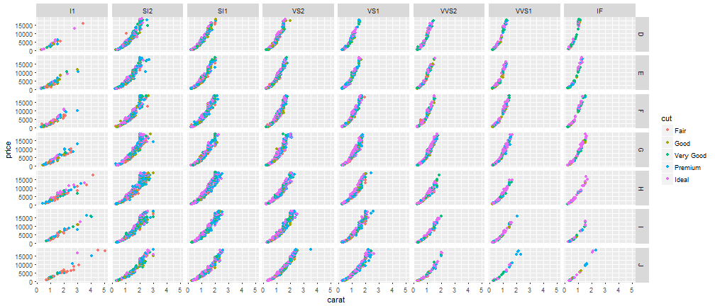

# Prediction Model

- The model is contributed by Solomon Messing (https://solomonmessing.wordpress.com/2014/01/19/visualization-series-the-scatterplot-or-how-to-use-data-so-you-dont-get-ripped-off/).

## Are you ready to buy a diamond? Check the price first here

### please run the following command in your R Console.

- library(shiny)
- runGitHub(“Coursera_DDP”, “ytu95035”)

#### “” has been changed to character by Rpres which is not recognized by R Console. Please retype double quote after you pass the comment to R Console. Thank you.

Due to my company's firewall, I can't publish Shiny app to R Server. This is the workaround to launch the applicaton. Really appreciate for your patience.